# Santa Barbara Stream Chemistry Clustering Analysis

Conner Smith

2/13/2022

```r
knitr::opts_chunk$set(echo = TRUE, message = FALSE, warning = FALSE)

library(tidyverse)
library(here)
library(NbClust)
library(cluster)
library(ggdendro)
library(dendextend)
library(factoextra)
```

## **Overview**

This analysis looks at stream chemistry data collected by the Santa Barbara Long Term Ecological Research Network through the Environmental Data Initiative. Data collection began in 2000 and is current through 2018. This analysis performs hierarchical clustering to create groupings of different stream sites based on several measured water chemistry variables. Several of these variables include:

- Ammonium (NH4);
- Nitrate (NO3);
- Phosphate (PO4);
- Total Suspended Solids

The analysis reveals several sites that stand apart from the rest in terms of different chemical loadings. Standalone groupings for some stream locations and high levels of Nitrates in particular, which have detrimental impacts on human health at high concentrations in drinking water, could determine the need for treatments to mitigate chemical inputs in these stream catchments.

### **Analysis**

```r
# Read in the data

stream_raw <- read_csv(here('data',
                            'sbc_lter_registered_stream_chemistry.csv'))

# -999.0 and -999 are invalid values
stream_clean <- stream_raw %>%
  na_if(-999.0) %>%
  na_if(-999)
```

The first part of this analysis creates mean values for all the variables and scales the range to allow for the hierarchical clustering below. Four sites (DV01, BC02, TO02, and SP02) have unreported values for several variables. These sites were not excluded from this analysis.

```r
# Need to clean and group the data to generate means for all variables by site, dropping the NA values.

stream_sub <- stream_clean %>%
  group_by(site_code) %>%
  summarize_all(~mean(.x, na.rm = TRUE))

# Note, dop_na command removes some streams that have no values recorded for some variables "NaN", keeping these in the data set

# Now scale the data (numeric values) to allow for clustering, use sites as rownames

stream_scale <- stream_sub %>%
  column_to_rownames('site_code') %>%
  select(2:11) %>%
  scale()
```

**Figure 1: Dendrogram of Clusters Based on Stream Site**

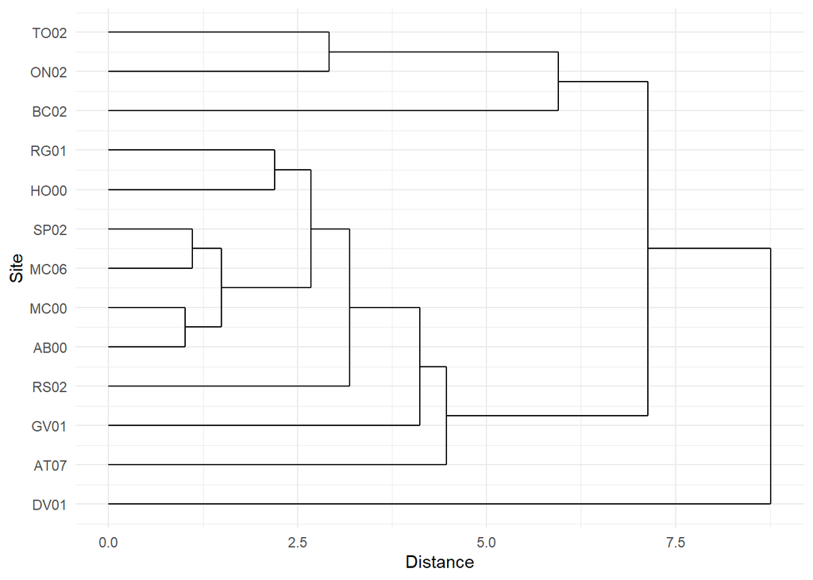

```r
# Hierarchical Cluster Analysis (agglomertive)

stream_dist <- dist(stream_scale, method = 'euclidian')

# Hierarchical clustering based on complete linkage

stream_hc_complete <- hclust(stream_dist, method = 'complete')

# convert the object into a 'dendrogram'

dend_compelte <- as.dendrogram(stream_hc_complete)

# Create  plot of the dendrogram

ggdendrogram(stream_hc_complete, rotate = TRUE) +
  theme_minimal() +
  xlab('Site') +
  ylab('Distance')
```

**Figure 1:** *This shows the results of the hierarchical clustering analysis across all stream sites in the LTER database.*

### **Key Takeaways:**

- This dendrogram shows the site DV01 in its own grouping, possibly as a result of abnormally high values for variables like scaled ammonium concentration.
- All other sites are included in a grouping with two sub-groupings.
- There are only three sites in one of these two sub-groupings, all of which have relatively high ammonia concentrations compared to other sites.
- Nine out of the 13 sites fit into one sub-grouping, indicating a closeness in observed variables for a majority of sites.
- This dendrogram could help water and environmental managers determine and prioritize stream catchments that stand further outside of primary clusters based on higher than average concenrations of certain chemical compounds.

### **Data Citation**

*Santa Barbara Coastal LTER and J. Melack. 2019. SBC LTER: Land: Stream chemistry in the Santa Barbara Coastal drainage area, ongoing since 2000 ver 16. Environmental Data Initiative. https://doi.org/10.6073/pasta/67a558a24ceed9a0a5bf5e46ab841174 (Accessed 2022-02-13).*